# CBC: gtsummary and ggplot2

Author

Affiliation

Jingzhe Zhang, Benjamin Langworthy

Department of Biostatistics, University of Minnesota

Published

February 26, 2026

```r
if (!requireNamespace("here", quietly = TRUE)) install.packages("here")
setwd(here::here())
```

# gtsummary

## Preparation

The `gtsummary` package provides an elegant and flexible way to create publication-ready analytical and summary tables.

**import data**

```r
library(tidyverse) #; theme_set(theme_bw())
library(gtsummary)
data(airquality)
```

**revealing**

```r
str(airquality)
```

```
'data.frame':   153 obs. of  6 variables:
 $ Ozone  : int  41 36 12 18 NA 28 23 19 8 NA ...
 $ Solar.R: int  190 118 149 313 NA NA 299 99 19 194 ...
 $ Wind   : num  7.4 8 12.6 11.5 14.3 14.9 8.6 13.8 20.1 8.6 ...
 $ Temp   : int  67 72 74 62 56 66 65 59 61 69 ...
 $ Month  : int  5 5 5 5 5 5 5 5 5 5 ...
 $ Day    : int  1 2 3 4 5 6 7 8 9 10 ...
```

**cleaning and creating binary indicator**

```r
aq <- airquality %>%
  select(Ozone, Temp, Wind, Solar.R) %>%
  na.omit() %>%
  mutate(
    high_ozone = ifelse(Ozone > 60, 1, 0)
  )

head(aq)
```

```
  Ozone Temp Wind Solar.R high_ozone
1    41   67  7.4     190          0
2    36   72  8.0     118          0
3    12   74 12.6     149          0
4    18   62 11.5     313          0
7    23   65  8.6     299          0
8    19   59 13.8      99          0
```

## Summarize

The first useful function in `gtsummary` is `tbl_summary` , which can create a table of descriptive statistics. Below we go through examples of how to use `tbl_summary` to create summary tables. Below we highlight how it can be used to create summary tables, and highlight some of the functionality including changing variable labels, changing which statistic is reported, and presenting a table split out by a binary variable.

```r
tbl_summary(aq)
```

| **Characteristic** | **N = 111**<sup>1</sup> |
| --- | --- |
| Ozone | 31 (18, 63) |
| Temp | 79 (71, 85) |
| Wind | 9.7 (7.4, 11.5) |
| Solar.R | 207 (112, 256) |
| high_ozone | 29 (26%) |

<sup>1</sup> Median (Q1, Q3); n (%)

By default `tbl_summary` reports the median (IQR) for continuous variables. We can change that to mean (sd) using the `statistic` option. We can also clean up the variable labels using the `label` option.

```r
tbl_summary(aq,label = list(Solar.R ="Solar Radiation",high_ozone = "Ozone > 60"),statistic = list(all_continuous() ~ "{mean} ({sd})"))
```

| **Characteristic** | **N = 111**<sup>1</sup> |
| --- | --- |
| Ozone | 42 (33) |
| Temp | 78 (10) |
| Wind | 9.9 (3.6) |
| Solar Radiation | 185 (91) |
| Ozone > 60 | 29 (26%) |

<sup>1</sup> Mean (SD); n (%)

If we want to split out the table by a categorical variable we can use the `by` option

```r
tbl_summary(aq,label = list(Solar.R ="Solar Radiation"), by = high_ozone)
```

| **Characteristic** | **0** N = 82<sup>1</sup> | **1** N = 29<sup>1</sup> |
| --- | --- | --- |
| Ozone | 23 (14, 36) | 84 (73, 97) |
| Temp | 76 (68, 81) | 89 (85, 92) |
| Wind | 10.6 (9.2, 12.6) | 6.3 (5.1, 8.0) |
| Solar Radiation | 191 (81, 256) | 223 (189, 255) |

<sup>1</sup> Median (Q1, Q3)

Below we highlight different formatting options

```r
tbl_summary(aq,label = list(Solar.R ="Solar Radiation"), by = high_ozone) %>%
  modify_header(label = "**Variable**") %>%
  add_overall() %>%
  bold_labels()
```

| **Variable** | **Overall** N = 111<sup>1</sup> | **0** N = 82<sup>1</sup> | **1** N = 29<sup>1</sup> |
| --- | --- | --- | --- |
| Ozone | 31 (18, 63) | 23 (14, 36) | 84 (73, 97) |
| Temp | 79 (71, 85) | 76 (68, 81) | 89 (85, 92) |
| Wind | 9.7 (7.4, 11.5) | 10.6 (9.2, 12.6) | 6.3 (5.1, 8.0) |
| Solar Radiation | 207 (112, 256) | 191 (81, 256) | 223 (189, 255) |

<sup>1</sup> Median (Q1, Q3)

## Statistical testing

```r
tbl_summary(aq, by = high_ozone) %>%
  add_p()
```

| **Characteristic** | **0** N = 82<sup>1</sup> | **1** N = 29<sup>1</sup> | **p-value**<sup>2</sup> |
| --- | --- | --- | --- |
| Ozone | 23 (14, 36) | 84 (73, 97) | <0.001 |
| Temp | 76 (68, 81) | 89 (85, 92) | <0.001 |
| Wind | 10.6 (9.2, 12.6) | 6.3 (5.1, 8.0) | <0.001 |
| Solar.R | 191 (81, 256) | 223 (189, 255) | 0.045 |

<sup>1</sup> Median (Q1, Q3)  
<sup>2</sup> Wilcoxon rank sum test

If we want to report the mean (sd) and use the t.test instead of the Wilcoxon test we can use the options below.

```r
tbl_summary(aq, by = high_ozone,statistic = list(all_continuous() ~ "{mean} ({sd})")) %>% add_p(test = list(all_continuous() ~ "t.test"))
```

| **Characteristic** | **0** N = 82<sup>1</sup> | **1** N = 29<sup>1</sup> | **p-value**<sup>2</sup> |
| --- | --- | --- | --- |
| Ozone | 25 (14) | 90 (24) | <0.001 |
| Temp | 74 (8) | 88 (5) | <0.001 |
| Wind | 11.1 (3.1) | 6.7 (2.6) | <0.001 |
| Solar.R | 171 (100) | 225 (40) | <0.001 |

<sup>1</sup> Mean (SD)  
<sup>2</sup> Welch Two Sample t-test

## Linear model

Above we show how we can use `gtsummary` for summary tables using `tbl_summary`. It can also be used to make well formatted tables of statistical model output. We fit a model with ozone as the outcome and temperature, wind, and solar radiation as covariates.

```r
lm_fit <- lm(Ozone ~ Temp + Wind + Solar.R, data = aq)
```

### Regression

`tbl_regression` converts the regression output into a cleanly presented table.

```r
tbl_regression(
  lm_fit,
  estimate_fun = ~style_sigfig(.x, digits = 3) # without, default sig digit is 2
)
```

| **Characteristic** | **Beta** | **95% CI** | **p-value** |
| --- | --- | --- | --- |
| Temp | 1.65 | 1.15, 2.15 | <0.001 |
| Wind | -3.33 | -4.63, -2.04 | <0.001 |
| Solar.R | 0.060 | 0.014, 0.106 | 0.011 |

Abbreviation: CI = Confidence Interval

**I don’t know what is Solar R**

```r
# Similar to `tbl_summary` we can change the variable labels.
tbl_lm <- tbl_regression(
  lm_fit,label = list(Solar.R ="Solar Radiation"),
  estimate_fun = ~style_sigfig(.x, digits = 3) # without, default sig digit is 2
)

tbl_lm
```

| **Characteristic** | **Beta** | **95% CI** | **p-value** |
| --- | --- | --- | --- |
| Temp | 1.65 | 1.15, 2.15 | <0.001 |
| Wind | -3.33 | -4.63, -2.04 | <0.001 |
| Solar Radiation | 0.060 | 0.014, 0.106 | 0.011 |

Abbreviation: CI = Confidence Interval

### Logistic model

In addition to linear regression `tbl_regression` can handle most common models in R, such as `coxph` , and `lmer` . Here we will go through an example using logistic regression from `glm` .

```r
logit_fit <- glm(
  high_ozone ~ Temp + Wind + Solar.R,
  data = aq,
  family = binomial
)
```

Try to use `tbl_regression` function for a logistic regression!

**tbl_regression for logistic regression**

```r
tbl_regression(logit_fit)
```

| **Characteristic** | **log(OR)** | **95% CI** | **p-value** |
| --- | --- | --- | --- |
| Temp | 0.49 | 0.27, 0.81 | <0.001 |
| Wind | -0.62 | -1.1, -0.27 | 0.003 |
| Solar.R | 0.01 | 0.00, 0.02 | 0.2 |

Abbreviations: CI = Confidence Interval, OR = Odds Ratio

The table above reports the coefficients on the logit scale, but in general we want to report the odds ratios instead. `gtsummary` can give us these automatically using the `exponentiate = TRUE` option. Note that this can be useful for other models, such as the Cox proportional hazards model.

**OR in raw scale**

```r
tbl_logit <- tbl_regression(
  logit_fit,
  exponentiate = TRUE, label = list(Solar.R ="Solar Radiation")
)

tbl_logit
```

| **Characteristic** | **OR** | **95% CI** | **p-value** |
| --- | --- | --- | --- |
| Temp | 1.63 | 1.31, 2.25 | <0.001 |
| Wind | 0.54 | 0.33, 0.77 | 0.003 |
| Solar Radiation | 1.01 | 1.00, 1.02 | 0.2 |

Abbreviations: CI = Confidence Interval, OR = Odds Ratio

### Merge

In addition to output from simple models, `gtsummary` has useful options for combining the presentation of multiple models. One of these is `tbl_merge()` , which allows us to compare results horizontally across different models using a consistent table layout.

```r
tbl_merge(
  tbls = list(tbl_lm, tbl_logit),
  tab_spanner = c("**Linear Regression**", "**Logistic Regression**")
)
```

| **Characteristic** | **Linear Regression** **Beta** | **Linear Regression** **95% CI** | **Linear Regression** **p-value** | **Logistic Regression** **OR** | **Logistic Regression** **95% CI** | **Logistic Regression** **p-value** |
| --- | --- | --- | --- | --- | --- | --- |
| Temp | 1.65 | 1.15, 2.15 | <0.001 | 1.63 | 1.31, 2.25 | <0.001 |
| Wind | -3.33 | -4.63, -2.04 | <0.001 | 0.54 | 0.33, 0.77 | 0.003 |
| Solar Radiation | 0.060 | 0.014, 0.106 | 0.011 | 1.01 | 1.00, 1.02 | 0.2 |

Abbreviations: CI = Confidence Interval, OR = Odds Ratio

### Stack

Another example is `tbl_stack()` , which is ideal for presenting multiple related models in a single, readable table vertically.

```r
lm_fit1 <- lm(Ozone ~ Temp, data = aq)
lm_fit2 <- lm(Ozone ~ Temp + Wind, data = aq)
lm_fit3 <- lm(Ozone ~ Temp + Wind + Solar.R, data = aq)

tbl_lm1 <- tbl_regression(lm_fit1)
tbl_lm2 <- tbl_regression(lm_fit2)
tbl_lm3 <- tbl_regression(lm_fit3)

tbl_stack(
  tbls = list(tbl_lm1, tbl_lm2, tbl_lm3),
  group_header = c(
    "**Model 1: Temp only**",
    "**Model 2: Temp + Wind**",
    "**Model 3: Full model**"
  )
)
```

| **Characteristic** | **Beta** | **95% CI** | **p-value** |
| --- | --- | --- | --- |
| **Model 1: Temp only** |  |  |  |
| Temp | 2.4 | 2.0, 2.9 | <0.001 |
| **Model 2: Temp + Wind** |  |  |  |
| Temp | 1.8 | 1.3, 2.3 | <0.001 |
| Wind | -3.3 | -4.6, -2.0 | <0.001 |
| **Model 3: Full model** |  |  |  |
| Temp | 1.7 | 1.1, 2.2 | <0.001 |
| Wind | -3.3 | -4.6, -2.0 | <0.001 |
| Solar.R | 0.06 | 0.01, 0.11 | 0.011 |

Abbreviation: CI = Confidence Interval

```r
tbl_merge(
  tbls = list(tbl_lm1, tbl_lm2, tbl_lm3)
  #tab_spanner = c("**Linear Regression**", "**Logistic Regression**")
)
```

| **Characteristic** | **Table 1** **Beta** | **Table 1** **95% CI** | **Table 1** **p-value** | **Table 2** **Beta** | **Table 2** **95% CI** | **Table 2** **p-value** | **Table 3** **Beta** | **Table 3** **95% CI** | **Table 3** **p-value** |
| --- | --- | --- | --- | --- | --- | --- | --- | --- | --- |
| Temp | 2.4 | 2.0, 2.9 | <0.001 | 1.8 | 1.3, 2.3 | <0.001 | 1.7 | 1.1, 2.2 | <0.001 |
| Wind |  |  |  | -3.3 | -4.6, -2.0 | <0.001 | -3.3 | -4.6, -2.0 | <0.001 |
| Solar.R |  |  |  |  |  |  | 0.06 | 0.01, 0.11 | 0.011 |

Abbreviation: CI = Confidence Interval

# ggplot2

**import ggplot2**

```r
library(ggplot2)
```

In `ggplot2`, plots are constructed from three core components:

- **Data** – the dataset being visualized
- **Aesthetics (`aes`)** – what variables to map
- **Geometries (`geom_x`)** – how data are displayed (points, bars, lines)

## Example 1

**histogram of a single variable**

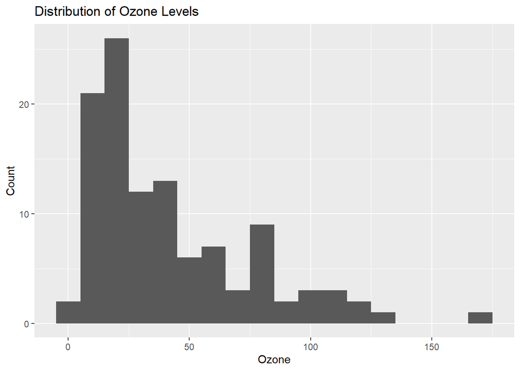

```r
ggplot(aq, aes(x = Ozone)) +
  geom_histogram(binwidth = 10) +
  labs(
    title = "Distribution of Ozone Levels",
    x = "Ozone",
    y = "Count"
  )
```

### Example 2

**scatter plot with regression line (use patchwork to show both)**

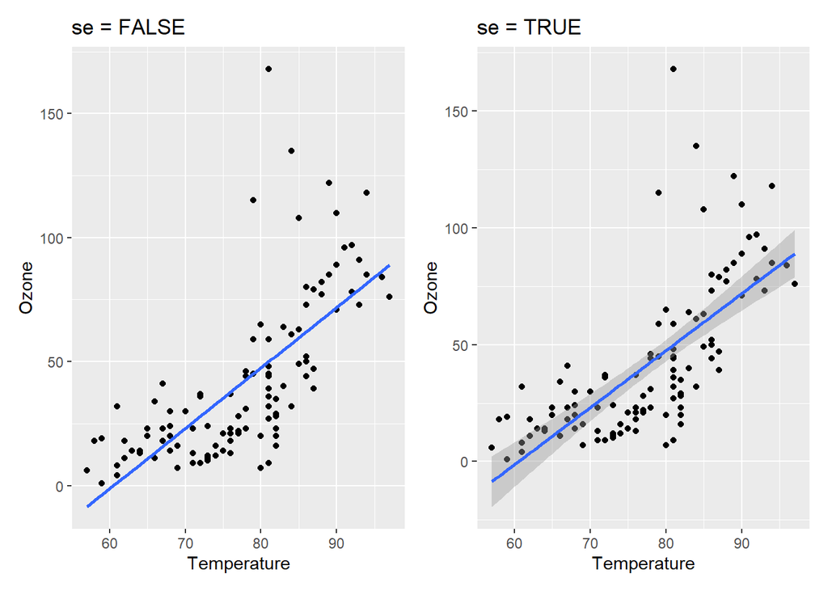

```r
library(patchwork)
p1 <- ggplot(aq, aes(x = Temp, y = Ozone)) +
  geom_point() +
  geom_smooth(method = "lm", se = FALSE) +
  labs(
    title = "se = FALSE",
    x = "Temperature",
    y = "Ozone"
  )

p2 <- ggplot(aq, aes(x = Temp, y = Ozone)) +
  geom_point() +
  geom_smooth(method = "lm", se = TRUE) +
  labs(
    title = "se = TRUE",
    x = "Temperature",
    y = "Ozone"
  )

p1 | p2
```

## Example 3

**another way to present multi-graphs when facing cateforical variable**

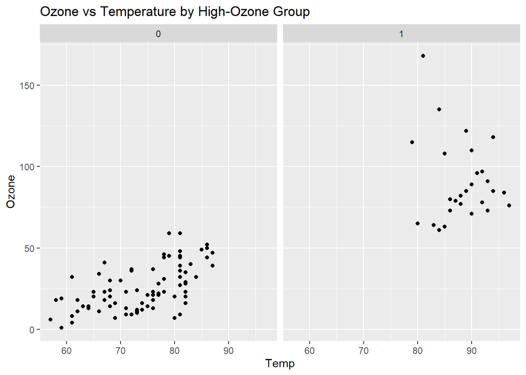

```r
ggplot(aq, aes(x = Temp, y = Ozone)) +
  geom_point() +
  facet_wrap(~ high_ozone) +
  labs(
    title = "Ozone vs Temperature by High-Ozone Group"
  )
```

### Example 4

**compare a continuous variable across two categories**

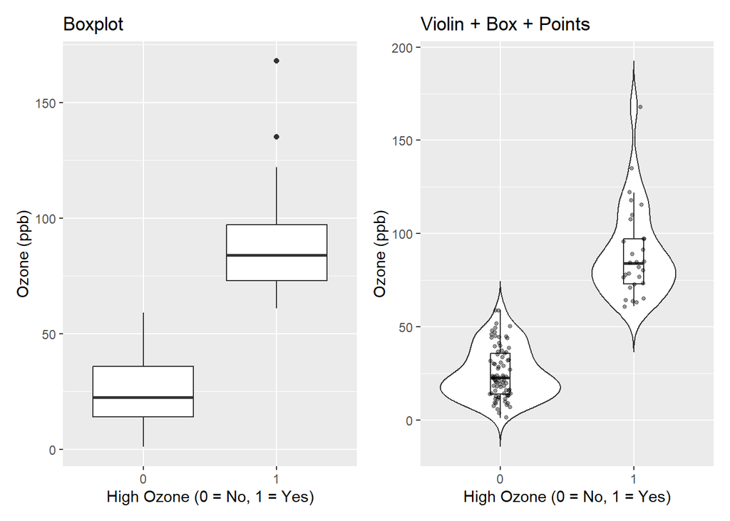

```r
p_box <- ggplot(aq, aes(x = factor(high_ozone), y = Ozone)) +
  geom_boxplot() +
  labs(
    title = "Boxplot",
    x = "High Ozone (0 = No, 1 = Yes)",
    y = "Ozone (ppb)"
  )

p_violin <- ggplot(aq, aes(x = factor(high_ozone), y = Ozone)) +
  geom_violin(trim = FALSE) +
  geom_boxplot(width = 0.15, outlier.shape = NA) +
  geom_jitter(width = 0.08, alpha = 0.4, size = 1) +
  labs(
    title = "Violin + Box + Points",
    x = "High Ozone (0 = No, 1 = Yes)",
    y = "Ozone (ppb)"
  )

p_box | p_violin
```

### Example 5

**Visualizing logistic regression**

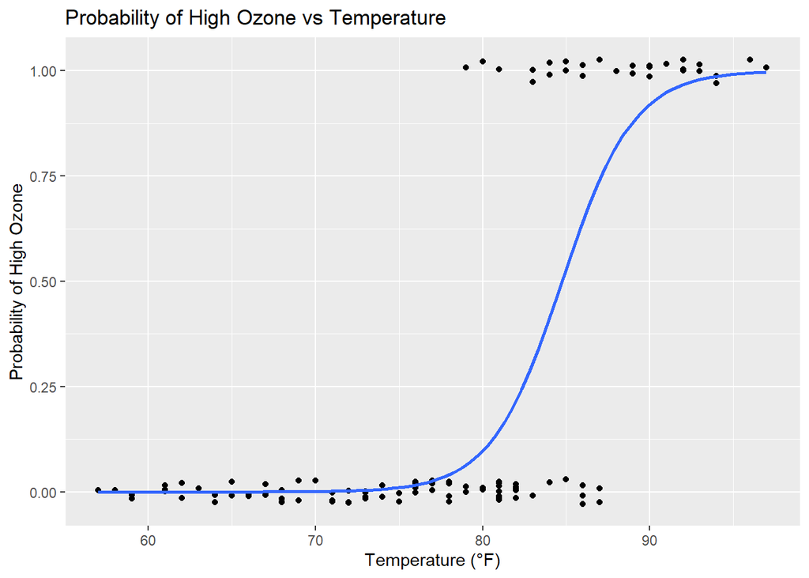

```r
ggplot(aq, aes(x = Temp, y = high_ozone)) +
  geom_jitter(height = 0.03, width = 0) +
  geom_smooth(
    method = "glm",
    method.args = list(family = binomial),
    se = FALSE
  ) +
  labs(
    title = "Probability of High Ozone vs Temperature",
    x = "Temperature (°F)",
    y = "Probability of High Ozone"
  )
```

# Let’s explore another dataset!

`Seatbelts` (Harvey and Durbin 1986) is a multiple time series, with columns.  
- **DriversKilled** - car drivers killed.  
- **drivers** - monthly totals of car drivers in Great Britain killed or seriously injured.  
- **front** - front-seat passengers killed or seriously injured.  
- **rear** - rear-seat passengers killed or seriously injured.  
- **kms** - distance driven.  
- **PetrolPrice** - petrol price.  
- **VanKilled** - number of van (‘light goods vehicle’) drivers.  
- **law** - 0/1: was the law in effect that month? (law to enforce seatbelt).

## Exploration Task 1: Summarize the dataset to get a better idea of it.

## Exploration Task 2: Compare Front vs Rear Seat

- Which seat had more deaths?

## Exploration Task 3: Relationship with Petrol Price

- Does petrol price affect the distance driven and drivers death?

## Exploration Task 4: Before and after the enforcement of seatbelt

- Does the introduction of seatbelt law affect the number of driver’s death?
- Does the proportion between front and reat seat injuries change?

## References

Harvey, A. C., and J. Durbin. 1986. “The Effects of Seat Belt Legislation on British Road Casualties: A Case Study in Structural Time Series Modelling.” *Journal of the Royal Statistical Society. Series A (General)* 149 (3): 187. https://doi.org/10.2307/2981553.